# ie360 hw

Alican Yılmaz

1/19/2021

# 1 Introduction

In this study, I will work on the Turkish Electricity Consumption Data, and make forecast on the daily electricity consumption of Turkey. The data is available on [EPİAŞ](https://seffaflik.epias.com.tr/transparency/tuketim/gerceklesen-tuketim/gercek-zamanli-tuketim.xhtml) website. The starting date of the data is “1st of January 2017” and ending date is “8th of January 2021” as indicated in the project description. My predictions will include the time zone of 14 days starting from 9th of January 2021. As mentioned in the project description, the core aim of the study is to make the data as stationary as possible, and to implement an “ARIMA model” for prediction, and finally to be able to test the overall performance of the prediction with some statistical error measures.

Outline of the study will be:

- Exploratory Data Analysis
  - Removing Outliers if necessary
- Time Series Decomposition
- Stationarity
- ACF/PACF Analysis
- Choosing the Right Model
- Forecasting First Model
- Forecasting Second Model
- Forecasting Third Model
- Testing the Results
- Conclusion

# 2 Exploratory Data Analysis

First, let’s read the data and do the necessary adjustments to make it ready for our analysis further.

```r
library('ggplot2')
library('forecast')
library('tseries')
library("data.table")
library("lubridate")
library("zoo")
```

The conversion from char to date and numeric is done first. Then daily mean consumption value of each date is calculated to further be used in our model.

First, let’s plot our model:

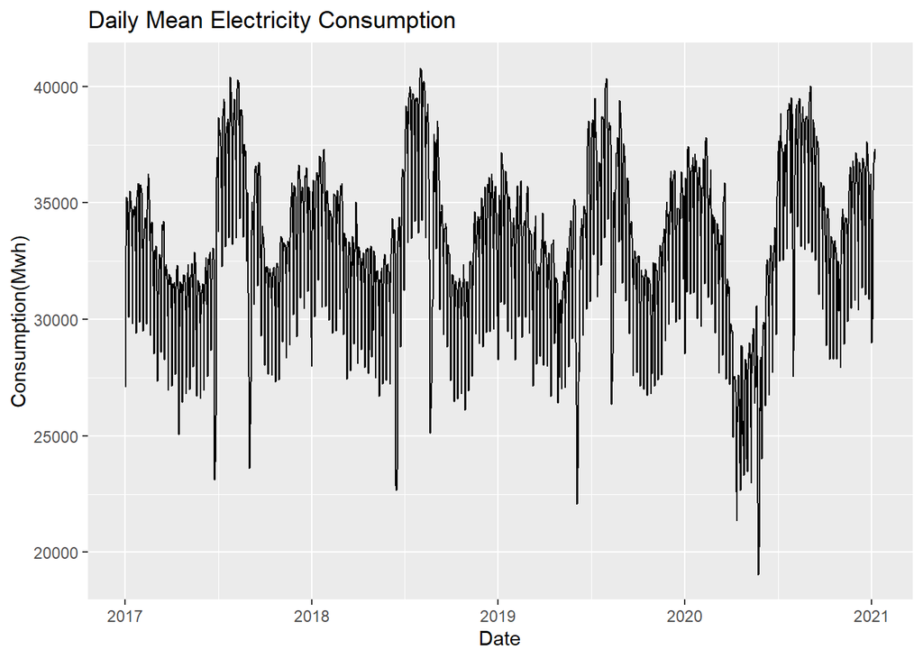

```r
ggplot(daily_consumption, aes(Date, mean_consumption)) + geom_line()  + labs(x="Date",y="Consumption(Mwh)",title="Daily Mean Electricity Consumption")
```

From the graph, it can be seen that, our data is not stationary(i.e variance and mean is not invariant of time). Also, we can observe some outliers during specific times which can affect our model significantly. First, we will try to remove the outliers with the help of `tsclean` function:

```r
is.ts(daily_consumption)
```

```
## [1] FALSE
```

```r
daily_consumption
```

```
##             Date mean_consumption
##    1: 2017-01-01         27099.66
##    2: 2017-01-02         33141.88
##    3: 2017-01-03         34769.59
##    4: 2017-01-04         35250.70
##    5: 2017-01-05         35109.35
##   ---
## 1465: 2021-01-04         35548.28
## 1466: 2021-01-05         36723.26
## 1467: 2021-01-06         37182.32
## 1468: 2021-01-07         37299.57
## 1469: 2021-01-08         36871.57
```

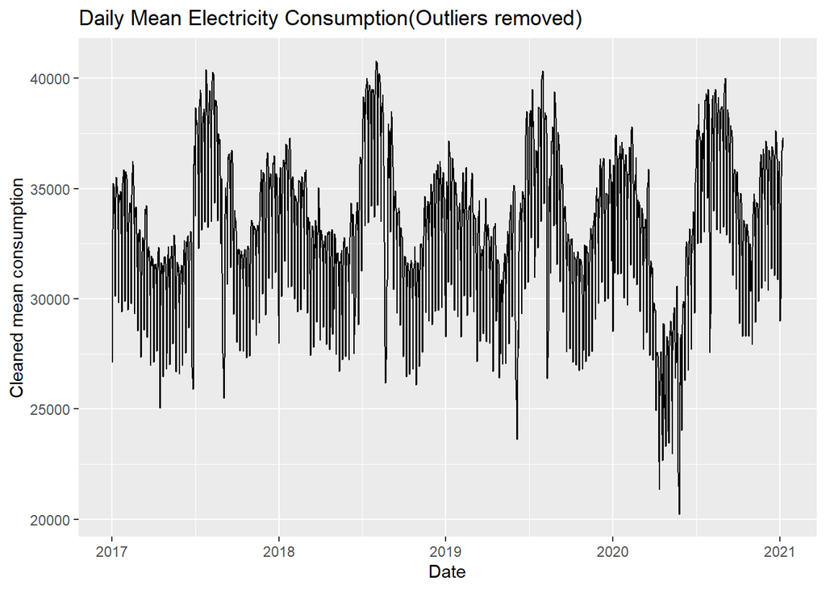

```r
cons_ts = ts(daily_consumption[, c('mean_consumption')])

daily_consumption$clean_cons = tsclean(cons_ts)

ggplot() +
  geom_line(data = daily_consumption, aes(x = Date, y = clean_cons)) + labs(x="Date",y='Cleaned mean consumption',title="Daily Mean Electricity Consumption(Outliers removed)")
```

Below, we can see the difference better. Some outliers were removed and linear interpolation is used on the series.

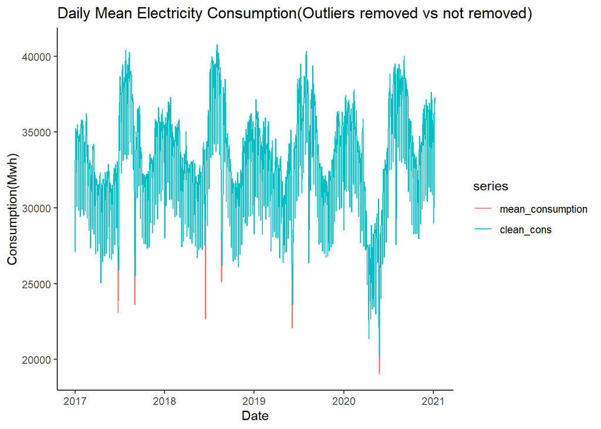

```r
ts_data<-ts(daily_consumption,start = c(2017, 1,1),frequency = 365)
autoplot(ts_data[,c("mean_consumption","clean_cons")]) +
  theme_classic()+
  labs( x="Date",y="Consumption(Mwh)",title=("Daily Mean Electricity Consumption(Outliers removed vs not removed)"))
```

From the plot below, we can see the general trend better:

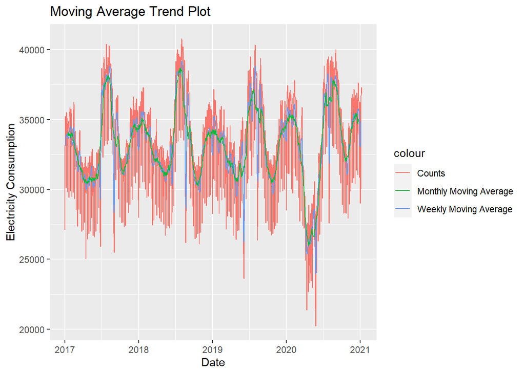

```r
daily_consumption$cons_ma = ma(daily_consumption$clean_cons, order=7) # using the clean count with no outliers
daily_consumption$cons_ma30 = ma(daily_consumption$clean_cons, order=30)


ggplot() +
  geom_line(data = daily_consumption, aes(x = Date, y = clean_cons, colour = "Counts")) +
  geom_line(data = daily_consumption, aes(x = Date, y = cons_ma,   colour = "Weekly Moving Average"))  +
  geom_line(data = daily_consumption, aes(x = Date, y = cons_ma30, colour = "Monthly Moving Average"))  +
  labs(y='Electricity Consumption',title="Moving Average Trend Plot")
```

# 3 Time Series Decomposition

Now, we can decompose the data:

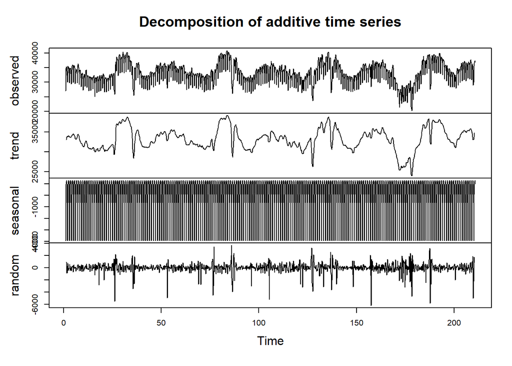

```r
ts_data1 = ts(na.omit(daily_consumption$clean_cons), frequency=7)
decomp = decompose(ts_data1)
plot(decomp)
```

Although, we still have some outlier days in our data,it seems a lot better than before in terms of randomness and normality.

# 4 Stationarity

We can check whether our data is stationary or not by `KPSS Unit Root Test`.

```r
require(urca)
unt_test=ur.kpss(decomp$random)
summary(unt_test)
```

```
##
## #######################
## # KPSS Unit Root Test #
## #######################
##
## Test is of type: mu with 7 lags.
##
## Value of test-statistic is: 0.0033
##
## Critical value for a significance level of:
##                 10pct  5pct 2.5pct  1pct
## critical values 0.347 0.463  0.574 0.739
```

# 5 ACF/PACF and Choosing the Right Model

Now, let’s check the autocorrelation with `Acf` and `Pacf` functions:

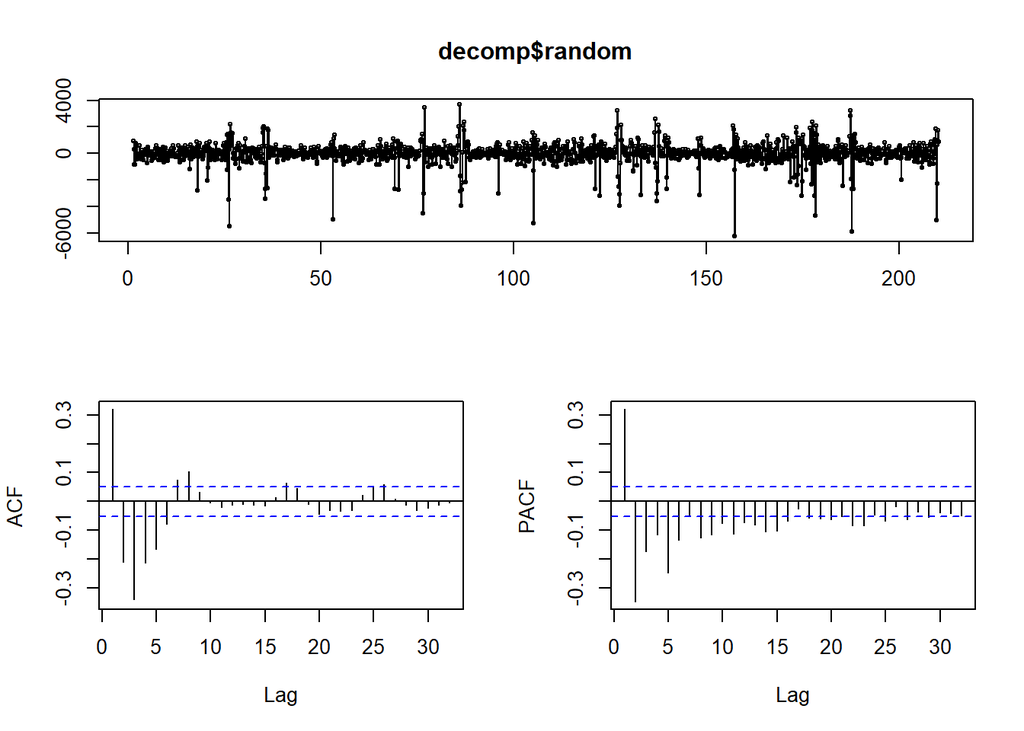

From the plots, we can see that there is significant autocorrelation in lag-1. We can try ARIMA(1,0,0) or ARIMA(0,0,1). And then, test the results with AIC and BIC criterion. Also, we can use `auto.arima` to find the best fit:

```r
library(stats)
fitted=auto.arima(decomp$random,seasonal=F,trace=T)
```

```
##
##  Fitting models using approximations to speed things up...
##
##  ARIMA(2,0,2)           with non-zero mean : Inf
##  ARIMA(0,0,0)           with non-zero mean : 23793.17
##  ARIMA(1,0,0)           with non-zero mean : 23637.33
##  ARIMA(0,0,1)           with non-zero mean : 23552.64
##  ARIMA(0,0,0)           with zero mean     : 23791.17
##  ARIMA(1,0,1)           with non-zero mean : 23554.56
##  ARIMA(0,0,2)           with non-zero mean : 23554.63
##  ARIMA(1,0,2)           with non-zero mean : 23241.4
##  ARIMA(1,0,3)           with non-zero mean : Inf
##  ARIMA(0,0,3)           with non-zero mean : Inf
##  ARIMA(2,0,1)           with non-zero mean : Inf
##  ARIMA(2,0,3)           with non-zero mean : Inf
##  ARIMA(1,0,2)           with zero mean     : 23239.95
##  ARIMA(0,0,2)           with zero mean     : 23552.62
##  ARIMA(1,0,1)           with zero mean     : 23552.55
##  ARIMA(2,0,2)           with zero mean     : Inf
##  ARIMA(1,0,3)           with zero mean     : Inf
##  ARIMA(0,0,1)           with zero mean     : 23550.63
##  ARIMA(0,0,3)           with zero mean     : Inf
##  ARIMA(2,0,1)           with zero mean     : Inf
##  ARIMA(2,0,3)           with zero mean     : Inf
##
##  Now re-fitting the best model(s) without approximations...
##
##  ARIMA(1,0,2)           with zero mean     : Inf
##  ARIMA(1,0,2)           with non-zero mean : Inf
##  ARIMA(0,0,1)           with zero mean     : 23550.61
##
##  Best model: ARIMA(0,0,1)           with zero mean
```

The best ARIMA model after auto.arima is applied is found to be ARIMA(0,0,1). Auto.arima takes into account AIC and BIC values when deciding the best model. The lower the value, the better the model is. Below, we can see the coefficients of the model and corresponding AIC and BIC values. .

```r
random<-decomp$random
model <- arima(random, order=c(0,0,1))
print(model)
```

```
##
## Call:
## arima(x = random, order = c(0, 0, 1))
##
## Coefficients:
##          ma1  intercept
##       0.4255     0.0916
## s.e.  0.0218    28.1788
##
## sigma^2 estimated as 571904:  log likelihood = -11773.3,  aic = 23552.61
```

```r
AIC(model)
```

```
## [1] 23552.61
```

```r
BIC(model)
```

```
## [1] 23568.47
```

Now, let’s check the residuals to understand better the result, and whether it is necessary to make any further improvement in our model.

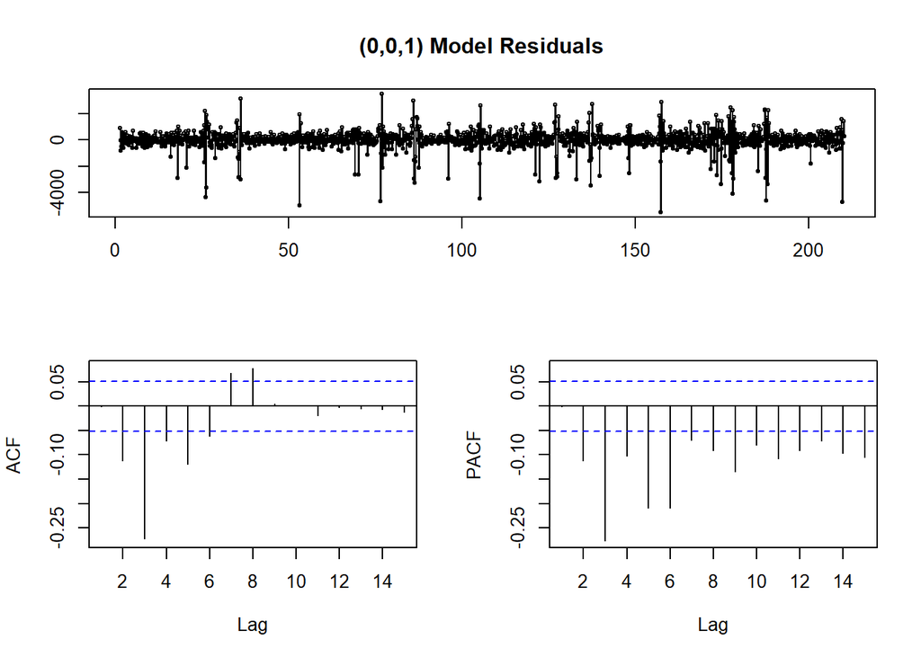

From the PACF, we can see gradual decrease in lag_3,lag_6 and so on. We can try to add seasonal component to the model.

```r
x=ts(decomp$random,freq=3)
model <-auto.arima(x, seasonal=T, trace=T)
```

```
##
##  Fitting models using approximations to speed things up...
##
##  ARIMA(2,0,2)(1,0,1)[3] with non-zero mean : Inf
##  ARIMA(0,0,0)           with non-zero mean : 23793.17
##  ARIMA(1,0,0)(1,0,0)[3] with non-zero mean : 23526.68
##  ARIMA(0,0,1)(0,0,1)[3] with non-zero mean : 23408.71
##  ARIMA(0,0,0)           with zero mean     : 23791.17
##  ARIMA(0,0,1)           with non-zero mean : 23552.64
##  ARIMA(0,0,1)(1,0,1)[3] with non-zero mean : 23407.19
##  ARIMA(0,0,1)(1,0,0)[3] with non-zero mean : 23441.68
##  ARIMA(0,0,1)(2,0,1)[3] with non-zero mean : 23410.23
##  ARIMA(0,0,1)(1,0,2)[3] with non-zero mean : 23407.24
##  ARIMA(0,0,1)(0,0,2)[3] with non-zero mean : 23404.28
##  ARIMA(0,0,0)(0,0,2)[3] with non-zero mean : 23528.76
##  ARIMA(1,0,1)(0,0,2)[3] with non-zero mean : 23350.54
##  ARIMA(1,0,1)(0,0,1)[3] with non-zero mean : 23349
##  ARIMA(1,0,1)           with non-zero mean : 23554.56
##  ARIMA(1,0,1)(1,0,1)[3] with non-zero mean : 23351.37
##  ARIMA(1,0,1)(1,0,0)[3] with non-zero mean : 23407.86
##  ARIMA(1,0,1)(1,0,2)[3] with non-zero mean : 23351.45
##  ARIMA(1,0,0)(0,0,1)[3] with non-zero mean : 23484.61
##  ARIMA(2,0,1)(0,0,1)[3] with non-zero mean : 23295.22
##  ARIMA(2,0,1)           with non-zero mean : Inf
##  ARIMA(2,0,1)(1,0,1)[3] with non-zero mean : 23300.07
##  ARIMA(2,0,1)(0,0,2)[3] with non-zero mean : 23297.11
##  ARIMA(2,0,1)(1,0,0)[3] with non-zero mean : 23396.38
##  ARIMA(2,0,1)(1,0,2)[3] with non-zero mean : 23300.08
##  ARIMA(2,0,0)(0,0,1)[3] with non-zero mean : 23361.84
##  ARIMA(2,0,2)(0,0,1)[3] with non-zero mean : Inf
##  ARIMA(1,0,2)(0,0,1)[3] with non-zero mean : 23132.79
##  ARIMA(1,0,2)           with non-zero mean : 23241.4
##  ARIMA(1,0,2)(1,0,1)[3] with non-zero mean : 23152.1
##  ARIMA(1,0,2)(0,0,2)[3] with non-zero mean : 23125.09
##  ARIMA(1,0,2)(1,0,2)[3] with non-zero mean : Inf
##  ARIMA(0,0,2)(0,0,2)[3] with non-zero mean : 23297.46
##  ARIMA(2,0,2)(0,0,2)[3] with non-zero mean : Inf
##  ARIMA(1,0,2)(0,0,2)[3] with zero mean     : 23123.46
##  ARIMA(1,0,2)(0,0,1)[3] with zero mean     : 23131.21
##  ARIMA(1,0,2)(1,0,2)[3] with zero mean     : Inf
##  ARIMA(1,0,2)(1,0,1)[3] with zero mean     : 23150.36
##  ARIMA(0,0,2)(0,0,2)[3] with zero mean     : 23295.44
##  ARIMA(1,0,1)(0,0,2)[3] with zero mean     : 23348.53
##  ARIMA(2,0,2)(0,0,2)[3] with zero mean     : Inf
##  ARIMA(0,0,1)(0,0,2)[3] with zero mean     : 23402.26
##  ARIMA(2,0,1)(0,0,2)[3] with zero mean     : 23295.09
##
##  Now re-fitting the best model(s) without approximations...
##
##  ARIMA(1,0,2)(0,0,2)[3] with zero mean     : Inf
##  ARIMA(1,0,2)(0,0,2)[3] with non-zero mean : Inf
##  ARIMA(1,0,2)(0,0,1)[3] with zero mean     : Inf
##  ARIMA(1,0,2)(0,0,1)[3] with non-zero mean : Inf
##  ARIMA(1,0,2)(1,0,1)[3] with zero mean     : Inf
##  ARIMA(1,0,2)(1,0,1)[3] with non-zero mean : Inf
##  ARIMA(1,0,2)           with non-zero mean : Inf
##  ARIMA(2,0,1)(0,0,2)[3] with zero mean     : 23294.83
##
##  Best model: ARIMA(2,0,1)(0,0,2)[3] with zero mean
```

```r
print(model)
```

```
## Series: x
## ARIMA(2,0,1)(0,0,2)[3] with zero mean
##
## Coefficients:
##           ar1      ar2     ma1     sma1    sma2
##       -0.4443  -0.2812  0.6717  -0.6193  0.0122
## s.e.   0.0491   0.0389  0.0353   0.0464  0.0309
##
## sigma^2 estimated as 478840:  log likelihood=-11641.38
## AIC=23294.77   AICc=23294.83   BIC=23326.5
```

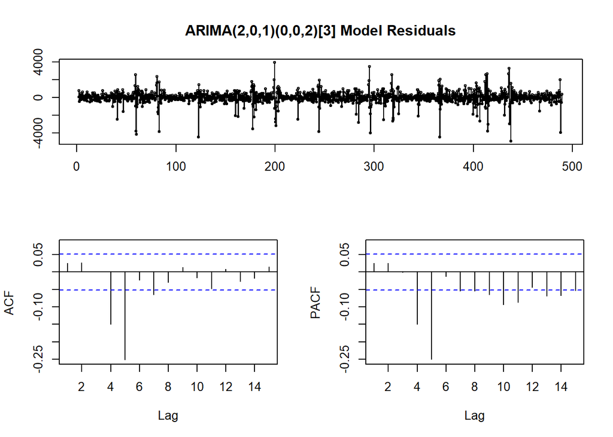

```r
tsdisplay(residuals(model), lag.max=15, main='ARIMA(2,0,1)(0,0,2)[3] Model Residuals')
```

After checking again the ACF and PACF, we observe a correlation at lag 4 and 5. Thus we can add MA(5) term to our model.

```r
model<-arima(x,order=c(2,0,5),seasonal = c(0,0,2))
print(model)
```

```
##
## Call:
## arima(x = x, order = c(2, 0, 5), seasonal = c(0, 0, 2))
##
## Coefficients:
##          ar1      ar2      ma1      ma2      ma3      ma4      ma5     sma1
##       0.4313  -0.3685  -0.3055  -0.1530  -0.0052  -0.2675  -0.2688  -0.3204
## s.e.  0.2523   0.2452   0.2488   0.2195   0.1125   0.0414   0.0411   0.1484
##          sma2  intercept
##       -0.1067    -0.0106
## s.e.   0.0700     0.0731
##
## sigma^2 estimated as 398887:  log likelihood = -11513.48,  aic = 23048.96
```

```r
BIC(model)
```

```
## [1] 23107.13
```

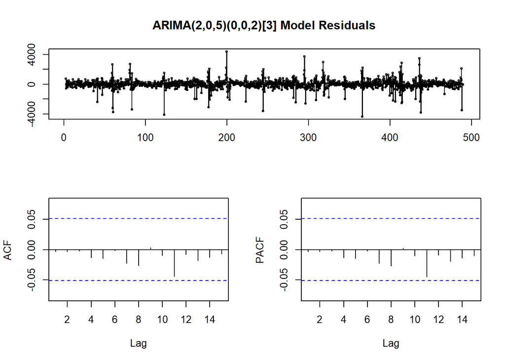

```r
tsdisplay(residuals(model), lag.max=15, main='ARIMA(2,0,5)(0,0,2)[3] Model Residuals')
```

# 6 Choosing the Right Model

Due to the increase in the lag_3 of ACF, we can try to add AR(3) component to our model which `auto.arima` didn’t trace in finding the best model:

```r
model <-arima(decomp$random, order=c(3,0,1))
print(model)
```

```
##
## Call:
## arima(x = decomp$random, order = c(3, 0, 1))
##
## Coefficients:
##          ar1      ar2     ar3      ma1  intercept
##       1.1261  -0.5834  0.0431  -1.0000    -0.0109
## s.e.  0.0261   0.0363  0.0262   0.0019     0.0960
##
## sigma^2 estimated as 412415:  log likelihood = -11537.51,  aic = 23087.02
```

AIC value is found to be “23087.03” which is lower than of the first model that auto.arima found. We can use this model, also!

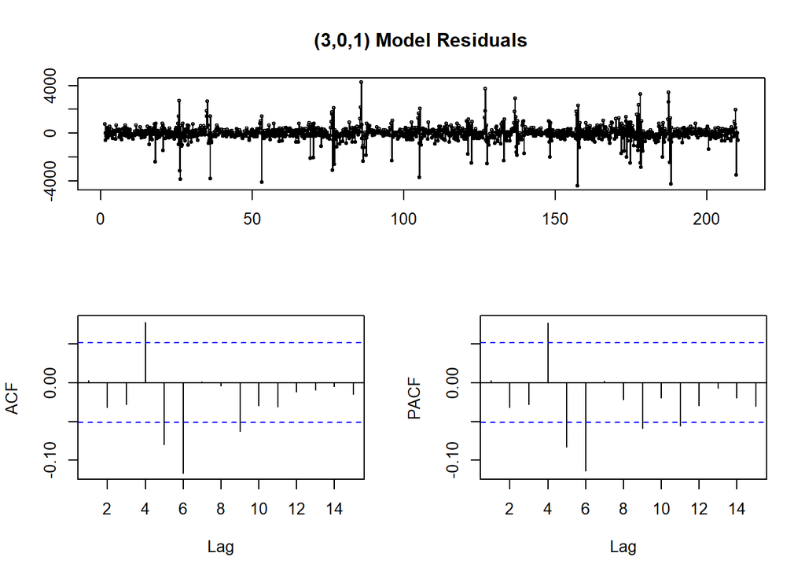

```r
tsdisplay(residuals(model), lag.max=15, main='(3,0,1) Model Residuals')
```

After ACF/PACF analysis and iteration process, we obtained two candidate model: * ARIMA(3,0,1) * ARIMA(2,0,5)(0,0,2)[3]

We can use both of them for our prediction, and then finally decide on which one is better by statistical accuracy tests.(e.g WMAPE, MAPE etc.)

Below, you can see the fitted model(ARIMA(3,0,1)) and random components, where blue line refers to fitted model and orange line refers to the random components.

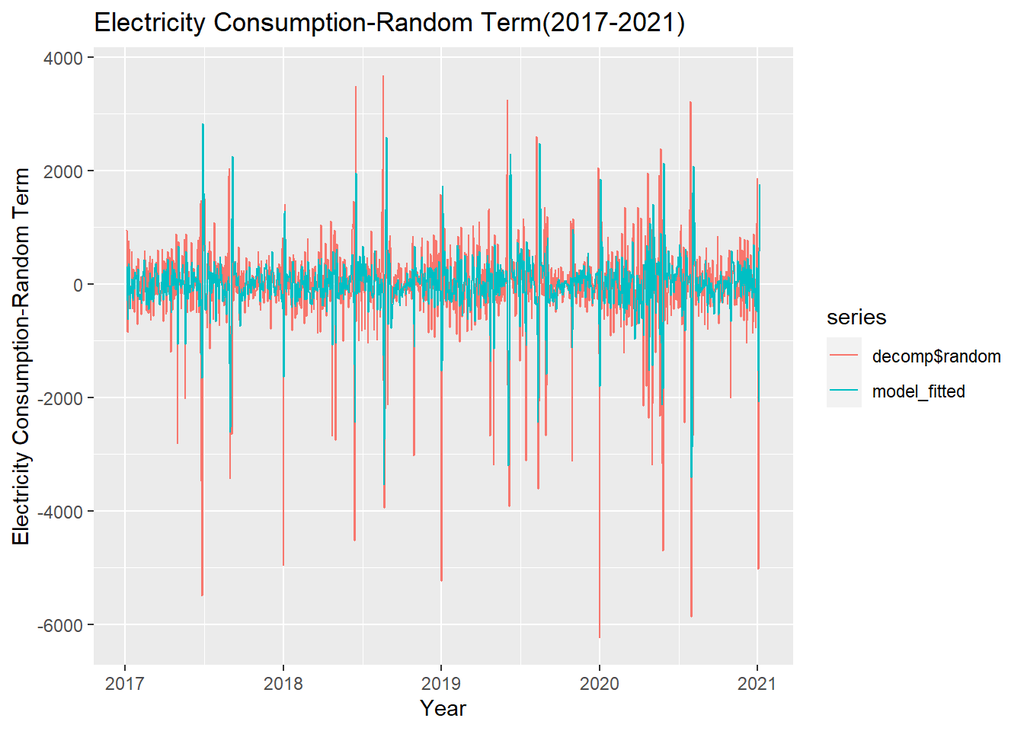

```r
model <-arima(decomp$random, order=c(3,0,1))
model_fitted<-decomp$random-residuals(model)
model_fitted_transformed <- model_fitted+decomp$trend+decomp$seasonal
# combining the two fr autoplot
comb_ts <- cbind(decomp$random, model_fitted)
ts_comb<-ts(comb_ts,start = c(2017, 1,1),frequency = 365)


autoplot(ts_comb, xlab = "Year", ylab = "Electricity Consumption-Random Term",main="Electricity Consumption-Random Term(2017-2021)")
```

```r
#points(model_fitted, type = "l", col = 2, lty = 2)
```

```r
library("tseries")
comb_ts <- cbind(ts_data1, model_fitted_transformed)
ts_comb<-ts(comb_ts,start = c(2017, 1,1),frequency = 365)
```

Similarly, you can see the fitted model(ARIMA(3,0,1)) after transformation and the real observed data, below.

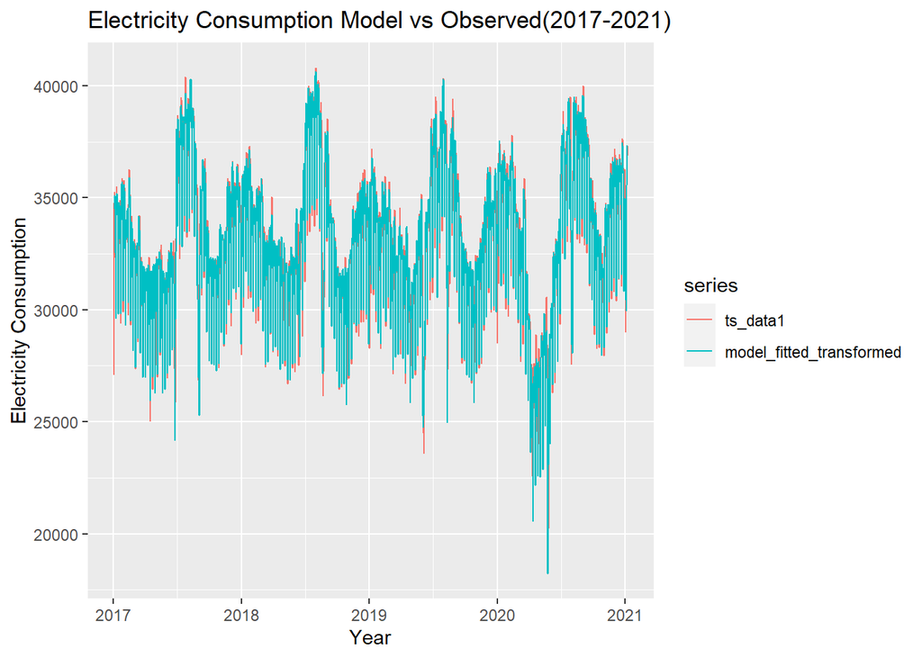

```r
autoplot(ts_comb, xlab = "Year", ylab = "Electricity Consumption",main="Electricity Consumption Model vs Observed(2017-2021)")
```

# 7 Forecasting with ARIMA(3,0,1) Model

Now, we can start forecasting our model:

```
## Time Series:
## Start = c(210, 7)
## End = c(212, 6)
## Frequency = 7
##  [1] 34045.97 30770.59 34843.60 35824.43 36088.74 36178.30 35866.99 34214.97
##  [9] 30916.28 34911.68 35823.38 36054.13 36142.86 35847.23
```

# 8 Forecasting with ARIMA(2,0,5)(0,0,2)[3] Model

```r
x=ts(decomp$random,freq=3)
model<-arima(x,order=c(2,0,5),seasonal = c(0,0,2))
model_forecast2<- predict(model, n.ahead = 14)$pred

last_trend_value <-as.numeric(rep(tail(decomp$trend[!is.na(decomp$trend)],1),14))
seasonality=as.numeric(tail(decomp$seasonal,14))
#back to the original series
model_forecast2=model_forecast2+last_trend_value+seasonality
model_forecast2
```

```
## Time Series:
## Start = c(490, 3)
## End = c(495, 1)
## Frequency = 3
##  [1] 33558.50 30829.15 35043.81 35807.47 35993.37 36123.35 35858.57 34221.02
##  [9] 30921.90 34916.03 35827.55 36056.80 36142.91 35845.49
```

# 9 Forecasting Third Approach

We know that our data have weekly seasonality. So, let’s first take difference of lag_7:

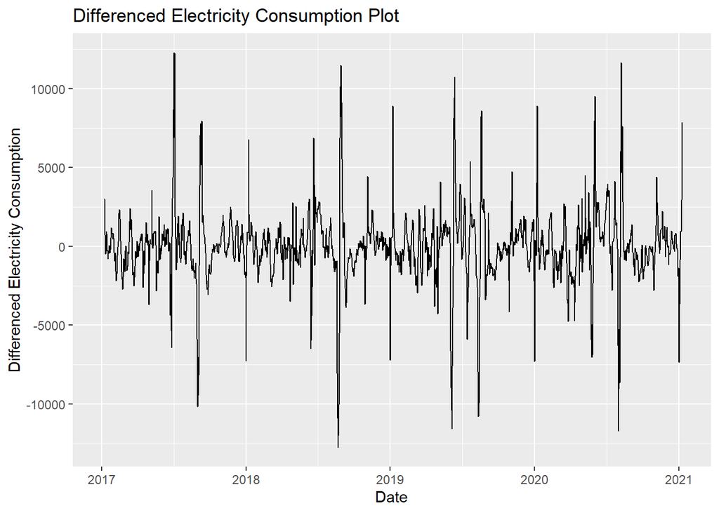

```r
daily_consumption[,differ:=clean_cons-shift(clean_cons,7)]
ggplot(daily_consumption,aes(x=Date)) + geom_line(aes(y=differ))+ labs(x="Date",y="Differenced Electricity Consumption",title="Differenced Electricity Consumption Plot")
```

```r
unt_test=ur.kpss(daily_consumption$differ)
summary(unt_test)
```

```
##
## #######################
## # KPSS Unit Root Test #
## #######################
##
## Test is of type: mu with 7 lags.
##
## Value of test-statistic is: 0.0134
##
## Critical value for a significance level of:
##                 10pct  5pct 2.5pct  1pct
## critical values 0.347 0.463  0.574 0.739
```

From the unit root test, we can now say that our data is stationary. Since we know that there is weekly seasonality, first the difference is taken and then arima model is applied. The best model is found to be `ARIMA(2,0,1)(2,0,0)[7]`.

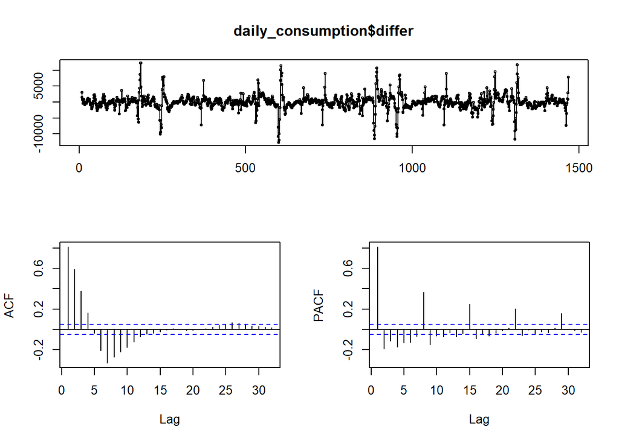

```r
tsdisplay(daily_consumption$differ)
```

```r
daily_consumption$differ<-ts(daily_consumption$differ,freq=7)
fitted=auto.arima(daily_consumption$differ,seasonal = T,trace=T)
```

```
##
##  Fitting models using approximations to speed things up...
##
##  ARIMA(2,0,2)(1,0,1)[7] with non-zero mean : Inf
##  ARIMA(0,0,0)           with non-zero mean : 26845.21
##  ARIMA(1,0,0)(1,0,0)[7] with non-zero mean : 24898.7
##  ARIMA(0,0,1)(0,0,1)[7] with non-zero mean : 25541.23
##  ARIMA(0,0,0)           with zero mean     : 26843.22
##  ARIMA(1,0,0)           with non-zero mean : 25257.36
##  ARIMA(1,0,0)(2,0,0)[7] with non-zero mean : 24754.89
##  ARIMA(1,0,0)(2,0,1)[7] with non-zero mean : Inf
##  ARIMA(1,0,0)(1,0,1)[7] with non-zero mean : Inf
##  ARIMA(0,0,0)(2,0,0)[7] with non-zero mean : 26651.26
##  ARIMA(2,0,0)(2,0,0)[7] with non-zero mean : 24724.53
##  ARIMA(2,0,0)(1,0,0)[7] with non-zero mean : 24863.79
##  ARIMA(2,0,0)(2,0,1)[7] with non-zero mean : Inf
##  ARIMA(2,0,0)(1,0,1)[7] with non-zero mean : Inf
##  ARIMA(3,0,0)(2,0,0)[7] with non-zero mean : 24726.92
##  ARIMA(2,0,1)(2,0,0)[7] with non-zero mean : 24724.48
##  ARIMA(2,0,1)(1,0,0)[7] with non-zero mean : 24854.34
##  ARIMA(2,0,1)(2,0,1)[7] with non-zero mean : Inf
##  ARIMA(2,0,1)(1,0,1)[7] with non-zero mean : Inf
##  ARIMA(1,0,1)(2,0,0)[7] with non-zero mean : 24725.13
##  ARIMA(3,0,1)(2,0,0)[7] with non-zero mean : 24729.59
##  ARIMA(2,0,2)(2,0,0)[7] with non-zero mean : 24730.16
##  ARIMA(1,0,2)(2,0,0)[7] with non-zero mean : 24726.46
##  ARIMA(3,0,2)(2,0,0)[7] with non-zero mean : 24728.75
##  ARIMA(2,0,1)(2,0,0)[7] with zero mean     : 24722.47
##  ARIMA(2,0,1)(1,0,0)[7] with zero mean     : 24852.34
##  ARIMA(2,0,1)(2,0,1)[7] with zero mean     : Inf
##  ARIMA(2,0,1)(1,0,1)[7] with zero mean     : Inf
##  ARIMA(1,0,1)(2,0,0)[7] with zero mean     : 24723.12
##  ARIMA(2,0,0)(2,0,0)[7] with zero mean     : 24722.53
##  ARIMA(3,0,1)(2,0,0)[7] with zero mean     : 24727.58
##  ARIMA(2,0,2)(2,0,0)[7] with zero mean     : 24728.15
##  ARIMA(1,0,0)(2,0,0)[7] with zero mean     : 24752.88
##  ARIMA(1,0,2)(2,0,0)[7] with zero mean     : 24724.45
##  ARIMA(3,0,0)(2,0,0)[7] with zero mean     : 24724.91
##  ARIMA(3,0,2)(2,0,0)[7] with zero mean     : 24726.75
##
##  Now re-fitting the best model(s) without approximations...
##
##  ARIMA(2,0,1)(2,0,0)[7] with zero mean     : 24716.13
##
##  Best model: ARIMA(2,0,1)(2,0,0)[7] with zero mean
```

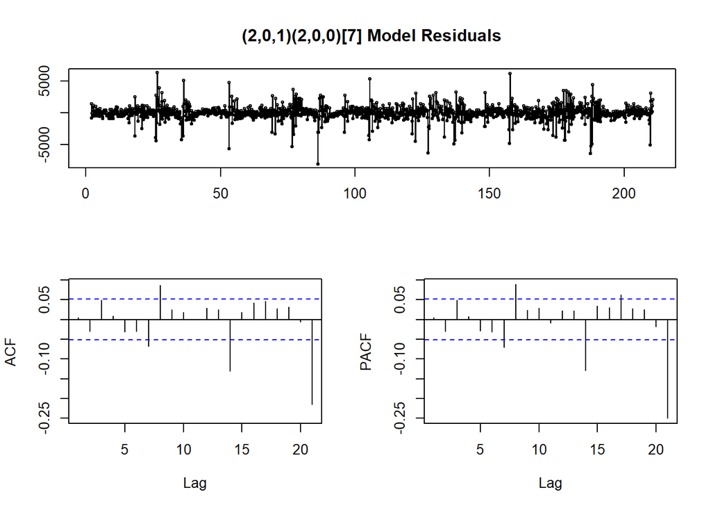

```r
tsdisplay(residuals(fitted), lag.max=21, main='(2,0,1)(2,0,0)[7] Model Residuals')
```

Let’s get the forecast results:

```r
fitted
```

```
## Series: daily_consumption$differ
## ARIMA(2,0,1)(2,0,0)[7] with zero mean
##
## Coefficients:
##          ar1      ar2      ma1     sar1     sar2
##       1.3096  -0.4247  -0.3284  -0.5984  -0.3083
## s.e.  0.1528   0.1307   0.1622   0.0270   0.0255
##
## sigma^2 estimated as 1277044:  log likelihood=-12352.03
## AIC=24716.07   AICc=24716.13   BIC=24747.79
```

```r
nahead=14
forecasted=forecast(fitted,h=nahead)
forecasted
```

```
##          Point Forecast      Lo 80    Hi 80      Lo 95    Hi 95
## 210.8571      5516.9772  4068.7425 6965.212  3302.0933 7731.861
## 211.0000      3377.9853  1349.0754 5406.895   275.0355 6480.935
## 211.1429      2665.9552   285.1243 5046.786  -975.2114 6307.122
## 211.2857      1810.4346  -782.8091 4403.678 -2155.5895 5776.459
## 211.4286      1252.5032 -1466.3949 3971.401 -2905.6925 5410.699
## 211.5714       146.6566 -2645.0361 2938.349 -4122.8689 4416.182
## 211.7143     -1650.8074 -4483.8772 1182.262 -5983.6138 2681.999
## 211.8571     -1584.0485 -4461.5742 1293.477 -5984.8443 2816.747
## 212.0000     -1331.7830 -4267.2033 1603.637 -5821.1209 3157.555
## 212.1429     -1211.0081 -4196.7237 1774.708 -5777.2661 3355.250
## 212.2857     -1147.4813 -4169.6945 1874.732 -5769.5575 3474.595
## 212.4286      -868.2830 -3914.4740 2177.908 -5527.0301 3790.464
## 212.5714      -876.6562 -3937.6487 2184.336 -5558.0403 3804.728
## 212.7143     -1350.0789 -4419.8298 1719.672 -6044.8577 3344.700
```

# 10 Testing the results

```r
#forecasted value with second approach
temporary=copy(daily_consumption)

test=daily_consumption[1:nahead]
test[,mean_consumption:=NA]
test$Date=max(daily_consumption$Date)+c(1:nahead)
test[,predicted_differ:=as.numeric(forecasted$mean)]

temporary=rbindlist(list(temporary,test),fill=T,use.names=T)
temporary[is.na(predicted_differ),predicted_differ:=differ] # past values are known

# transforming to the original scale
temporary[,forecastval:=predicted_differ+shift(mean_consumption,7)]
tail(temporary,14)
```

```
##           Date mean_consumption clean_cons  cons_ma cons_ma30     differ
##  1: 2021-01-09               NA   27099.66       NA        NA         NA
##  2: 2021-01-10               NA   33141.88       NA        NA         NA
##  3: 2021-01-11               NA   34769.59       NA        NA         NA
##  4: 2021-01-12               NA   35250.70 33082.40        NA         NA
##  5: 2021-01-13               NA   35109.35 33510.75        NA         NA
##  6: 2021-01-14               NA   33866.49 33719.85        NA         NA
##  7: 2021-01-15               NA   32339.15 33825.38        NA         NA
##  8: 2021-01-16               NA   30098.06 33759.60        NA 2998.40042
##  9: 2021-01-17               NA   34605.60 33761.83        NA 1463.71542
## 10: 2021-01-18               NA   35508.33 33895.29        NA  738.73583
## 11: 2021-01-19               NA   34790.24 34012.03        NA -460.45875
## 12: 2021-01-20               NA   35124.93 33973.37        NA   15.58083
## 13: 2021-01-21               NA   34800.69 33938.32        NA  934.20333
## 14: 2021-01-22               NA   33156.36 33824.53        NA  817.21417
##     predicted_differ forecastval
##  1:        5516.9772    35793.91
##  2:        3377.9853    33401.34
##  3:        2665.9552    38214.23
##  4:        1810.4346    38533.69
##  5:        1252.5032    38434.83
##  6:         146.6566    37446.23
##  7:       -1650.8074    35220.76
##  8:       -1584.0485          NA
##  9:       -1331.7830          NA
## 10:       -1211.0081          NA
## 11:       -1147.4813          NA
## 12:        -868.2830          NA
## 13:        -876.6562          NA
## 14:       -1350.0789          NA
```

Since our data takes difference at lag_7, last 7 forecasted values could not be calculated. However, we can take those forecasted values as if they were real values, to obtain the last 7 days forecast prediction too.

```r
temporary$mean_consumption[1470:1476]=temporary$forecastval[1470:1476]
temporary[,forecastval:=predicted_differ+shift(mean_consumption,7)]
tail(temporary,14)
```

```
##           Date mean_consumption clean_cons  cons_ma cons_ma30     differ
##  1: 2021-01-09         35793.91   27099.66       NA        NA         NA
##  2: 2021-01-10         33401.34   33141.88       NA        NA         NA
##  3: 2021-01-11         38214.23   34769.59       NA        NA         NA
##  4: 2021-01-12         38533.69   35250.70 33082.40        NA         NA
##  5: 2021-01-13         38434.83   35109.35 33510.75        NA         NA
##  6: 2021-01-14         37446.23   33866.49 33719.85        NA         NA
##  7: 2021-01-15         35220.76   32339.15 33825.38        NA         NA
##  8: 2021-01-16               NA   30098.06 33759.60        NA 2998.40042
##  9: 2021-01-17               NA   34605.60 33761.83        NA 1463.71542
## 10: 2021-01-18               NA   35508.33 33895.29        NA  738.73583
## 11: 2021-01-19               NA   34790.24 34012.03        NA -460.45875
## 12: 2021-01-20               NA   35124.93 33973.37        NA   15.58083
## 13: 2021-01-21               NA   34800.69 33938.32        NA  934.20333
## 14: 2021-01-22               NA   33156.36 33824.53        NA  817.21417
##     predicted_differ forecastval
##  1:        5516.9772    35793.91
##  2:        3377.9853    33401.34
##  3:        2665.9552    38214.23
##  4:        1810.4346    38533.69
##  5:        1252.5032    38434.83
##  6:         146.6566    37446.23
##  7:       -1650.8074    35220.76
##  8:       -1584.0485    34209.86
##  9:       -1331.7830    32069.56
## 10:       -1211.0081    37003.22
## 11:       -1147.4813    37386.21
## 12:        -868.2830    37566.54
## 13:        -876.6562    36569.57
## 14:       -1350.0789    33870.68
```

Now that we have two different forecasted value for the upcoming 14 days, we can see which one did better with the help of statistical tests. Before testing the results with real values, I need to obtain the real observed data of the forecasted dates as I did in the beginning.

```r
consumption_14_Days = fread('test-09012021-23012021.csv', header=TRUE)
setnames(consumption_14_Days,"Tüketim Miktarý (MWh)","cons")
consumption_14_Days[,Tarih:=as.Date(Tarih,"%d.%m.%Y")]
consumption_14_Days[,cons:=as.numeric(gsub(",", "", cons))]
daily_consumption_14=consumption_14_Days[,list(mean_consumption=mean(cons,na.rm=T)),by=list(Tarih)]
daily_consumption_14=daily_consumption_14[1:14]
```

Now that, we obtain the real values for the forecasted day, we can calculate how well our forecast predicted. Below you can see the accuracy test function:

```r
error_test <- function(actual, forecasted){
  n=length(actual)
  error = actual-forecasted
  mean=mean(actual)
  sd=sd(actual)
  bias = sum(error)/sum(actual)
  mape = sum(abs(error/actual))/n
  mad = sum(abs(error))/n
  wmape = mad/mean
  df = data.frame(n,mean,sd,bias,mape,mad,wmape)
  return(df)
}
```

After putting the results into the `error_test` function, we observe that WMAPE value of the second model is found to have the lowest WMAPE value. Thus, we can select `ARIMA(2,0,5)(0,0,2)[3]` as the best model among the three.

```r
acurracy_for_first_model=error_test(daily_consumption_14$mean_consumption,model_forecast)
acurracy_for_first_model
```

```
##    n     mean       sd      bias     mape      mad    wmape
## 1 14 37.04231 2.564443 -939.1009 940.3837 34786.47 939.1009
```

```r
accuracy_for_second_model=error_test(daily_consumption_14$mean_consumption, model_forecast2)
accuracy_for_second_model
```

```
##    n     mean       sd     bias     mape      mad   wmape
## 1 14 37.04231 2.564443 -938.362 939.6144 34759.09 938.362
```

```r
accuracy_for_third_model=error_test(daily_consumption_14$mean_consumption, temporary[1470:1483,forecastval])
accuracy_for_third_model
```

```
##    n     mean       sd      bias     mape      mad    wmape
## 1 14 37.04231 2.564443 -974.1796 976.4304 36085.86 974.1796
```

# 11 Conclusion

In this work, I tried to predict the Turkish electricity consumption based on the previous data which is obtained from [EPİAŞ](https://seffaflik.epias.com.tr/transparency/tuketim/gerceklesen-tuketim/gercek-zamanli-tuketim.xhtml). First, the data is analyzed and visualized to understand it better. The data was not stationary as expected, since it has weekly, monthly seasonality, moving trend and also some outliers which correspond to religious holidays, special days etc. Still, we managed to obtain a stationary series with some approaches. We also tested our results statistically. With the help of ACF/PACF plots, we tried to obtain best ARIMA models iteratively. Finally, we had 3 different ARIMA models to be tested. For testing, we get the original data of the forecasted day and applied WMAPE to decide on which model predicts better. Based on that test, we found that `ARIMA(2,0,5)(0,0,2)[3]` model predicted slightly better than the other two.